# Anaylsis of ATAC-seq in embryos depleted for Zelda

Kaelan (1028-02098-001-001)

November 01, 2022

# 1. Introduction

The goal of this analysis is to compare ATAC-seq time course data generated in wild-type, OregonR embryos to the same experiments performed in embryos depleted for Zelda (Zelda RNAi). Note that UAS-zld-shRNA lines were provided by Christine Rushlow’s lab and Zelda-depleted embryos were generated through crossing with an MTD-Gal4 line (see methods). We will specifically use this data to compare our experimental accessibility in the absence of Zelda to ChromBPNet model predictions, and we will also use this to investigate the differences between high and low affinity Zelda motifs mapped by BPNet. The plots generated here make up approxiamtely half of Figure 3, including d-g.

# 2. Computational Setup

```r
#Standard packages
library(rtracklayer) ; library(GenomicRanges); library(magrittr) ; library(Biostrings)
library(ggplot2) ; library(reshape2); library(plyranges); library(Rsamtools); library(ggpubr)
library(dplyr); library(data.table); library(patchwork); library(readr); library(testit); library(cowplot)

#KNITR Options
setwd("/l/Zeitlinger/ZeitlingerLab/Manuscripts/Zelda_and_Nucleosomes/Analysis/analysis/")
options(knitr.figure_dir="figures/14_zelda_depletion_atac/", java.parameters = "- Xmx6g")

#Lab sources
source("scripts/r/granges_common.r")
source("scripts/r/metapeak_common.r")
source("scripts/r/knitr_common.r")
source("scripts/r/caching.r")
source("scripts/r/metapeak_functions.r")

#Specific sources
library(ggseqlogo)
library(BSgenome.Dmelanogaster.UCSC.dm6)
library(rhdf5)
source("scripts/r/motif_functions.r")

#Pre-existing variables
modisco_dir <- 'bpnet/modisco/fold1/'
tasks <- c('Zld','Dl','Twi','Bcd','Cad','GAF')
threads <- 5
bsgenome<-BSgenome.Dmelanogaster.UCSC.dm6
```

# 3. Import relevant data for this analysis

```r
# motifs

motifs.df <- readr::read_tsv('/l/Zeitlinger/ZeitlingerLab/Manuscripts/Zelda_and_Nucleosomes/Analysis/analysis/tsv/mapped_motifs/all_instances_curated_1based.tsv.gz') %>%
  as.data.frame()

# ATAC replicate coverage list: for DESeq2, we will use 3 replicates of all 4 time points, both in wt and Zld- embryos.

atac.bw.zld.list <- list(wt_1to15_rep1 = '/l/Zeitlinger/ZeitlingerLab/Manuscripts/Zelda_and_Nucleosomes/Analysis/data/bw/dm6/atac/individual/orer_1to15_atac_4_cutsites.bw',
                         wt_1to15_rep2 = '/l/Zeitlinger/ZeitlingerLab/Manuscripts/Zelda_and_Nucleosomes/Analysis/data/bw/dm6/atac/individual/orer_1to15_atac_6_cutsites.bw',
                         wt_1to15_rep3 = '/l/Zeitlinger/ZeitlingerLab/Manuscripts/Zelda_and_Nucleosomes/Analysis/data/bw/dm6/atac/individual/orer_1to15_atac_7_cutsites.bw',
                         zldrnai_1to15_rep1 = '/l/Zeitlinger/ZeitlingerLab/Manuscripts/Zelda_and_Nucleosomes/Analysis/data/bw/dm6/atac/individual/zldrnai_1to15_atac_1_cutsites.bw',
                         zldrnai_1to15_rep2 = '/l/Zeitlinger/ZeitlingerLab/Manuscripts/Zelda_and_Nucleosomes/Analysis/data/bw/dm6/atac/individual/zldrnai_1to15_atac_2_cutsites.bw',
                         zldrnai_1to15_rep3 = '/l/Zeitlinger/ZeitlingerLab/Manuscripts/Zelda_and_Nucleosomes/Analysis/data/bw/dm6/atac/individual/zldrnai_1to15_atac_3_cutsites.bw',
                         wt_15to2_rep1 = '/l/Zeitlinger/ZeitlingerLab/Manuscripts/Zelda_and_Nucleosomes/Analysis/data/bw/dm6/atac/individual/orer_15to2_atac_4_cutsites.bw',
                         wt_15to2_rep2 = '/l/Zeitlinger/ZeitlingerLab/Manuscripts/Zelda_and_Nucleosomes/Analysis/data/bw/dm6/atac/individual/orer_15to2_atac_6_cutsites.bw',
                         wt_15to2_rep3 = '/l/Zeitlinger/ZeitlingerLab/Manuscripts/Zelda_and_Nucleosomes/Analysis/data/bw/dm6/atac/individual/orer_15to2_atac_7_cutsites.bw',
                         zldrnai_15to2_rep1 = '/l/Zeitlinger/ZeitlingerLab/Manuscripts/Zelda_and_Nucleosomes/Analysis/data/bw/dm6/atac/individual/zldrnai_15to2_atac_1_cutsites.bw',
                         zldrnai_15to2_rep2 = '/l/Zeitlinger/ZeitlingerLab/Manuscripts/Zelda_and_Nucleosomes/Analysis/data/bw/dm6/atac/individual/zldrnai_15to2_atac_2_cutsites.bw',
                         zldrnai_15to2_rep3 = '/l/Zeitlinger/ZeitlingerLab/Manuscripts/Zelda_and_Nucleosomes/Analysis/data/bw/dm6/atac/individual/zldrnai_15to2_atac_3_cutsites.bw',
                         wt_2to25_rep1 = '/l/Zeitlinger/ZeitlingerLab/Manuscripts/Zelda_and_Nucleosomes/Analysis/data/bw/dm6/atac/individual/orer_2to25_atac_4_cutsites.bw',
                         wt_2to25_rep2 = '/l/Zeitlinger/ZeitlingerLab/Manuscripts/Zelda_and_Nucleosomes/Analysis/data/bw/dm6/atac/individual/orer_2to25_atac_6_cutsites.bw',
                         wt_2to25_rep3 = '/l/Zeitlinger/ZeitlingerLab/Manuscripts/Zelda_and_Nucleosomes/Analysis/data/bw/dm6/atac/individual/orer_2to25_atac_7_cutsites.bw',
                         zldrnai_2to25_rep1 = '/l/Zeitlinger/ZeitlingerLab/Manuscripts/Zelda_and_Nucleosomes/Analysis/data/bw/dm6/atac/individual/zldrnai_2to25_atac_1_cutsites.bw',
                         zldrnai_2to25_rep2 = '/l/Zeitlinger/ZeitlingerLab/Manuscripts/Zelda_and_Nucleosomes/Analysis/data/bw/dm6/atac/individual/zldrnai_2to25_atac_2_cutsites.bw',
                         zldrnai_2to25_rep3 = '/l/Zeitlinger/ZeitlingerLab/Manuscripts/Zelda_and_Nucleosomes/Analysis/data/bw/dm6/atac/individual/zldrnai_2to25_atac_3_cutsites.bw',
                         wt_25to3_rep1 = '/l/Zeitlinger/ZeitlingerLab/Manuscripts/Zelda_and_Nucleosomes/Analysis/data/bw/dm6/atac/individual/orer_25to3_atac_4_cutsites.bw',
                         wt_25to3_rep2 = '/l/Zeitlinger/ZeitlingerLab/Manuscripts/Zelda_and_Nucleosomes/Analysis/data/bw/dm6/atac/individual/orer_25to3_atac_6_cutsites.bw',
                         wt_25to3_rep3 = '/l/Zeitlinger/ZeitlingerLab/Manuscripts/Zelda_and_Nucleosomes/Analysis/data/bw/dm6/atac/individual/orer_25to3_atac_7_cutsites.bw',
                         zldrnai_25to3_rep1 = '/l/Zeitlinger/ZeitlingerLab/Manuscripts/Zelda_and_Nucleosomes/Analysis/data/bw/dm6/atac/individual/zldrnai_25to3_atac_1_cutsites.bw',
                         zldrnai_25to3_rep2 = '/l/Zeitlinger/ZeitlingerLab/Manuscripts/Zelda_and_Nucleosomes/Analysis/data/bw/dm6/atac/individual/zldrnai_25to3_atac_2_cutsites.bw',
                         zldrnai_25to3_rep3 = '/l/Zeitlinger/ZeitlingerLab/Manuscripts/Zelda_and_Nucleosomes/Analysis/data/bw/dm6/atac/individual/zldrnai_25to3_atac_3_cutsites.bw')
```

# 4. Determine differential accessibility using DESeq2

## 4.1. Format and calculate counts using cutsite information

```r
# Define peaks--these are non-overlapping and evenly-sized

peaks.gr <- rtracklayer::import('/l/Zeitlinger/ZeitlingerLab/Manuscripts/Zelda_and_Nucleosomes/Analysis/data/narrowpeak/atac_orer_all_peaks.narrowpeak') %>%
  GenomicRanges::reduce(ignore.strand = T) %>%
  GenomicRanges::resize(2114, 'center') %>%
  plyranges::mutate(peak_id = 1:length(.))

# Calculate the counts across all peaks

counts.zld.df<-mclapply(atac.bw.zld.list, function(x){
  regionSums(peaks.gr, x)
}, mc.cores = 8) %>% as.data.frame()
colnames(counts.zld.df)<-names(atac.bw.zld.list)

# Set conditions for the DESeq2 model

peak_condition_zld.df<-data.frame(condition = c(rep('wt_1to15', 3), rep('zldrnai_1to15', 3), rep('wt_15to2', 3), rep('zldrnai_15to2', 3), rep('wt_2to25', 3), rep('zldrnai_2to25', 3), rep('wt_25to3', 3), rep('zldrnai_25to3', 3)))
peak_condition_zld.df$condition<- factor(peak_condition_zld.df$condition, levels = c("wt_1to15", "zldrnai_1to15", "wt_15to2","zldrnai_15to2", "wt_2to25","zldrnai_2to25", "wt_25to3","zldrnai_25to3"))
rownames(peak_condition_zld.df)<-names(atac.bw.zld.list)
```

## 4.2. Set up differential model

```r
library(DESeq2)

dds_zld <- DESeqDataSetFromMatrix(countData = counts.zld.df,
                              colData = peak_condition_zld.df,
                              design = ~ condition)
model_zld <- DESeq(dds_zld)
```

## 4.3. Gather time point results

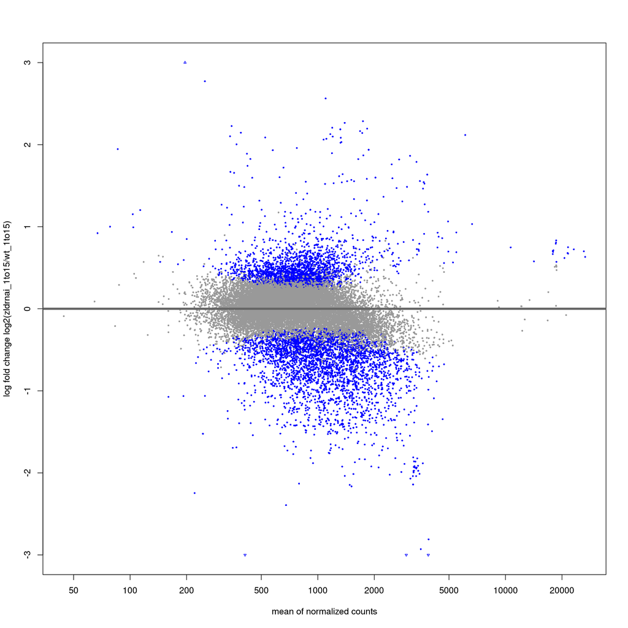

```r
t1_res.zld.df <- results(model_zld, contrast = c("condition","zldrnai_1to15","wt_1to15"), alpha = 0.05)
plotMA(t1_res.zld.df, ylim=c(-3,3), ylab = 'log fold change log2(zldrnai_1to15/wt_1to15)')
```

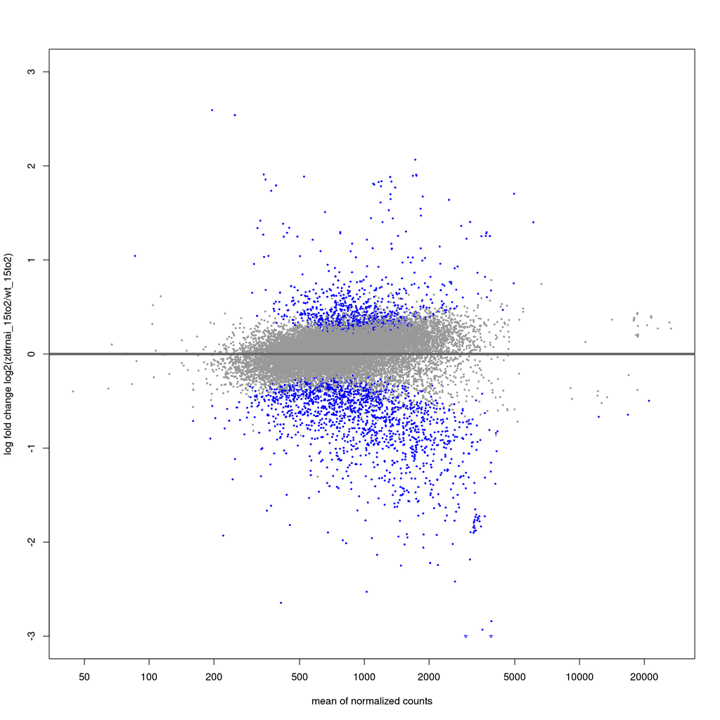

```r
t1.zld.ma <- ggplot(as.data.frame(t1_res.zld.df), aes(x = baseMean, y = log2FoldChange))+
  geom_hline(yintercept = 0, color = 'black', linetype = 'dotted')+
  geom_point(aes(color = padj <0.05), size = .2) +
  #geom_point(color = 'gray', size = .2) +
  scale_y_continuous(limits = c(-3, 3), name = 'log2(zldrnai_1to15/wt_1to15)')+
  scale_x_continuous(limits = c(0,10000), breaks = c(0,2000,4000,6000,8000,10000))+
  xlab("Mean normalized ATAC-seq signal") +
  ggtitle("MA plot at 1-1.5 hr") +
  theme_cowplot()

t2_res.zld.df <- results(model_zld, contrast = c("condition","zldrnai_15to2","wt_15to2"), alpha = 0.05)
plotMA(t2_res.zld.df, ylim=c(-3,3), ylab = 'log fold change log2(zldrnai_15to2/wt_15to2)')
```

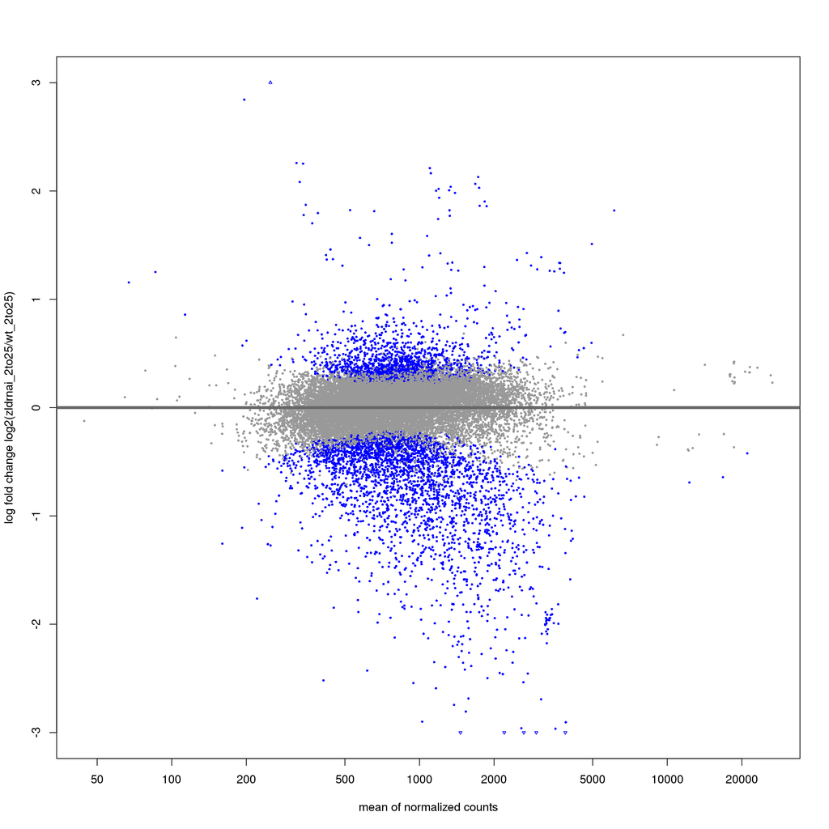

```r
t2.zld.ma <- ggplot(as.data.frame(t2_res.zld.df), aes(x = baseMean, y = log2FoldChange))+
  geom_hline(yintercept = 0, color = 'black', linetype = 'dotted')+
  geom_point(aes(color = padj <0.05), size = .2) +
  #geom_point(color = 'gray', size = .2) +
  scale_y_continuous(limits = c(-3, 3), name = 'log2(zldrnai_15to2/wt_15to2)')+
  scale_x_continuous(limits = c(0,10000), breaks = c(0,2000,4000,6000,8000,10000))+
  xlab("Mean normalized ATAC-seq signal") +
  ggtitle("MA plot at 1.5-2 hr") +
  theme_cowplot()

t3_res.zld.df <- results(model_zld, contrast = c("condition","zldrnai_2to25","wt_2to25"), alpha = 0.05)
plotMA(t3_res.zld.df, ylim=c(-3,3), ylab = 'log fold change log2(zldrnai_2to25/wt_2to25)')
```

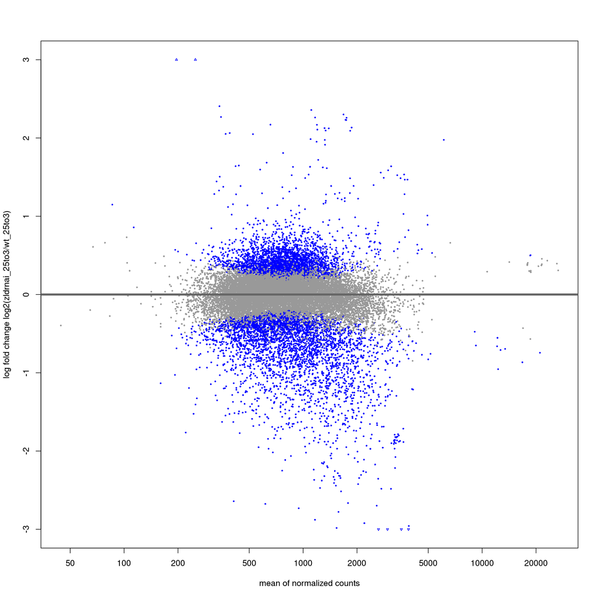

```r
t3.zld.ma <- ggplot(as.data.frame(t3_res.zld.df), aes(x = baseMean, y = log2FoldChange))+
  geom_hline(yintercept = 0, color = 'black', linetype = 'dotted')+
  geom_point(aes(color = padj <0.05), size = .2) +
  #geom_point(color = 'gray', size = .2) +
  scale_y_continuous(limits = c(-3, 3), name = 'log2(zldrnai_2to25/wt_2to25)')+
  scale_x_continuous(limits = c(0,10000), breaks = c(0,2000,4000,6000,8000,10000))+
  xlab("Mean normalized ATAC-seq signal") +
  ggtitle("MA plot at 2-2.5 hr") +
  theme_cowplot()

t4_res.zld.df <- results(model_zld, contrast = c("condition","zldrnai_25to3","wt_25to3"), alpha = 0.05)
plotMA(t4_res.zld.df, ylim=c(-3,3), ylab = 'log fold change log2(zldrnai_25to3/wt_25to3)')
```

```r
t4.zld.ma <- ggplot(as.data.frame(t4_res.zld.df), aes(x = baseMean, y = log2FoldChange))+
  geom_hline(yintercept = 0, color = 'black', linetype = 'dotted')+
  geom_point(aes(color = padj <0.05), size = .2) +
  #geom_point(color = 'gray', size = .2) +
  scale_y_continuous(limits = c(-3, 3), name = 'log2(zldrnai_25to3/wt_25to3)')+
  scale_x_continuous(limits = c(0,10000), breaks = c(0,2000,4000,6000,8000,10000))+
  xlab("Mean normalized ATAC-seq signal") +
  ggtitle("MA plot at 2.5-3 hr") +
  theme_cowplot()

zld_maplots <- t1.zld.ma + t2.zld.ma + t3.zld.ma + t4.zld.ma
ggsave("zld_effect_ma_plots.pdf", plot = zld_maplots, path = "figures/14_zelda_depletion_atac/", width = 25, height = 20, units = "cm")
ggsave("zld_effect_ma_plots.png", plot = zld_maplots, path = "figures/14_zelda_depletion_atac/", width = 25, height = 20, units = "cm")
```

## 4.4. Plot results at enhancers

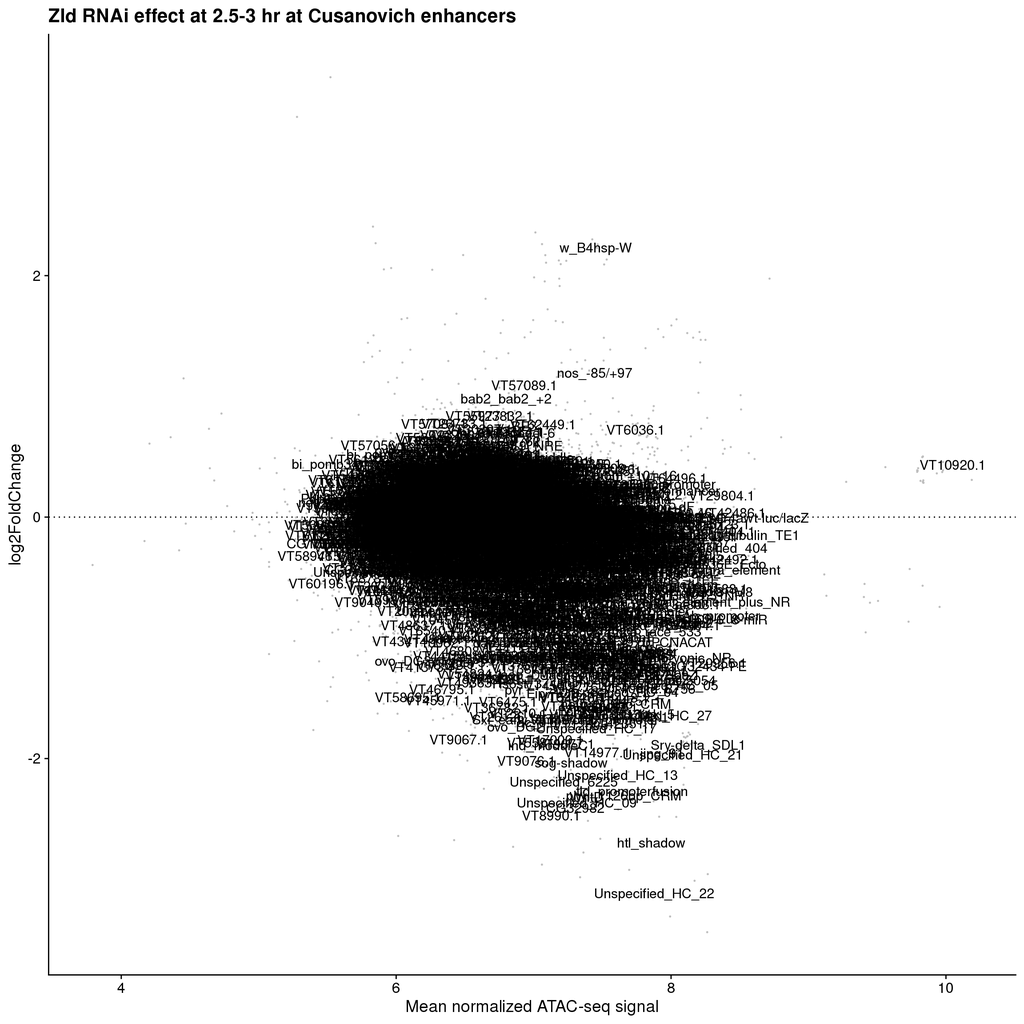

```r
# import enhancers and find overlaps

cus_enhancers.gr <- rtracklayer::import('/l/Zeitlinger/ZeitlingerLab/Manuscripts/Zelda_and_Nucleosomes/Analysis/data/published/enhancers/cusanovich/cusanovich_dm6_enhancers.bed')

peaks.gr$enhancer_name <- NA
enhancer.ov <- findOverlaps(peaks.gr, cus_enhancers.gr, ignore.strand = T)
peaks.gr$enhancer_name[enhancer.ov@from]<-cus_enhancers.gr$name[enhancer.ov@to]

# use the 2.5-3 hr time point results here

peaks_w_de.df <- cbind(peaks.gr %>% as.data.frame, t4_res.zld.df) %>%
  dplyr::mutate(has_enhancer = ifelse(is.na(enhancer_name), 'no','yes'))

#Plot with DE results

zld_effect_at_cus_enhancers <- ggplot(peaks_w_de.df, aes(x = log(baseMean), y = log2FoldChange))+
  geom_hline(yintercept = 0, color = 'black', linetype = 'dotted')+
  geom_point(color = 'gray', size = .2) +
  geom_text(aes(label = enhancer_name), size = 4)+
  #scale_y_continuous(limits = c(-2.5, 2.5), name = 'log2(zld_rnai_25to3/wt_25to3)')+
  xlab("Mean normalized ATAC-seq signal") +
  ggtitle("Zld RNAi effect at 2.5-3 hr at Cusanovich enhancers") +
  theme_cowplot()
zld_effect_at_cus_enhancers
```

```r
ggsave("zld_effect_at_cus_enhancers.pdf", plot = zld_effect_at_cus_enhancers, path = "figures/14_zelda_depletion_atac", width = 25, height = 20, units = "cm")
ggsave("zld_effect_at_cus_enhancers.png", plot = zld_effect_at_cus_enhancers, path = "figures/14_zelda_depletion_atac", width = 25, height = 20, units = "cm")
```

## 4.5. Map DESeq2 results back to peaks

```r
# overlap with peaks

peaks_w_de_t1.df <- cbind(peaks.gr %>% as.data.frame, t1_res.zld.df) %>%
  dplyr::mutate(has_enhancer = ifelse(is.na(enhancer_name), 'no','yes'))
peaks_w_de_t2.df <- cbind(peaks.gr %>% as.data.frame, t2_res.zld.df) %>%
  dplyr::mutate(has_enhancer = ifelse(is.na(enhancer_name), 'no','yes'))
peaks_w_de_t3.df <- cbind(peaks.gr %>% as.data.frame, t3_res.zld.df) %>%
  dplyr::mutate(has_enhancer = ifelse(is.na(enhancer_name), 'no','yes'))
peaks_w_de_t4.df <- cbind(peaks.gr %>% as.data.frame, t4_res.zld.df) %>%
  dplyr::mutate(has_enhancer = ifelse(is.na(enhancer_name), 'no','yes'))

# make GRanges for export

peaks_w_de_t1.gr <- peaks_w_de_t1.df %>%
  dplyr::mutate(timepoint = '1to15') %>%
  makeGRangesFromDataFrame(keep.extra.columns = TRUE)

peaks_w_de_t2.gr <- peaks_w_de_t2.df %>%
  dplyr::mutate(timepoint = '15to2') %>%
  makeGRangesFromDataFrame(keep.extra.columns = TRUE)

peaks_w_de_t3.gr <- peaks_w_de_t3.df %>%
  dplyr::mutate(timepoint = '2to25') %>%
  makeGRangesFromDataFrame(keep.extra.columns = TRUE)

peaks_w_de_t4.gr <- peaks_w_de_t4.df %>%
  dplyr::mutate(timepoint = '25to3') %>%
  makeGRangesFromDataFrame(keep.extra.columns = TRUE)
```

## 4.6. Save DESeq2 results

```r
deseq_at_peaks.list <- list('zldrnai_1to15/wt_1to15' = peaks_w_de_t1.gr,
                            'zldrnai_15to2/wt_15to2' = peaks_w_de_t2.gr,
                            'zldrnai_2to25/wt_2to25' = peaks_w_de_t3.gr,
                            'zldrnai_25to3/wt_25to3' = peaks_w_de_t4.gr)
saveRDS(deseq_at_peaks.list, '/l/Zeitlinger/ZeitlingerLab/Manuscripts/Zelda_and_Nucleosomes/Analysis/data/deseq2/zldrnai/zld_depletion_deseq_timepoints_at_orer_1to3_atac_peaks.RData')
```

## 4.7. Export DESeq2 results as .txt file for GEO

```r
peaks_w_de_t1.df <- as.data.frame(peaks_w_de_t1.gr)
peaks_w_de_t1.df$deseq <- "zldrnai_1to15/wt_1to15"
peaks_w_de_t2.df <- as.data.frame(peaks_w_de_t2.gr)
peaks_w_de_t2.df$deseq <- "zldrnai_15to2/wt_15to2"
peaks_w_de_t3.df <- as.data.frame(peaks_w_de_t3.gr)
peaks_w_de_t3.df$deseq <- "zldrnai_2to25/wt_2to25"
peaks_w_de_t4.df <- as.data.frame(peaks_w_de_t4.gr)
peaks_w_de_t4.df$deseq <- "zldrnai_25to3/wt_25to3"

all_zld_deseq.df <- rbind(peaks_w_de_t1.df,peaks_w_de_t2.df,peaks_w_de_t3.df,peaks_w_de_t4.df)

write.table(all_zld_deseq.df,'/l/Zeitlinger/ZeitlingerLab/Manuscripts/Zelda_and_Nucleosomes/Analysis/data/deseq2/zldrnai/zld_depletion_deseq_timepoints_at_orer_1to3_atac_peaks.txt', row.names=FALSE)
```

# 5. Effects of Zelda depletion on chromatin accessibility

## 5.1. Combine all time points effects with motifs

```r
# Summarize from all time points into one total de onject

peaks_w_de_t1.df$t1_log2FC <- peaks_w_de_t1.df$log2FoldChange
peaks_w_de_t2.df$t2_log2FC <- peaks_w_de_t2.df$log2FoldChange
peaks_w_de_t3.df$t3_log2FC <- peaks_w_de_t3.df$log2FoldChange
peaks_w_de_t4.df$t4_log2FC <- peaks_w_de_t4.df$log2FoldChange

peaks_w_all_time_de.df <- peaks_w_de_t4.df[,1:7]
peaks_w_all_time_de.df$t1_log2FC <- peaks_w_de_t1.df$log2FoldChange
peaks_w_all_time_de.df$t2_log2FC <- peaks_w_de_t2.df$log2FoldChange
peaks_w_all_time_de.df$t3_log2FC <- peaks_w_de_t3.df$log2FoldChange
peaks_w_all_time_de.df$t4_log2FC <- peaks_w_de_t4.df$log2FoldChange

# Map peaks with DESeq information back to motifs

motifs_vs_peaks.ov<-findOverlaps(motifs.df %>% makeGRangesFromDataFrame(), peaks.gr, ignore.strand = T)
motifs.df$peak_id<-NA
motifs.df$peak_id[motifs_vs_peaks.ov@from]<-peaks.gr$peak_id[motifs_vs_peaks.ov@to]

motifs_across_peaks.df<-motifs.df %>%
  dplyr::filter(!is.na(peak_id)) %>%
  dplyr::left_join(., peaks_w_all_time_de.df %>% dplyr::select(-c(seqnames, start, end, width, strand)), by = 'peak_id') %>%
  as.data.frame()
```

## 5.2. Plot effects of Zelda depletion at regions with and without Zelda motifs

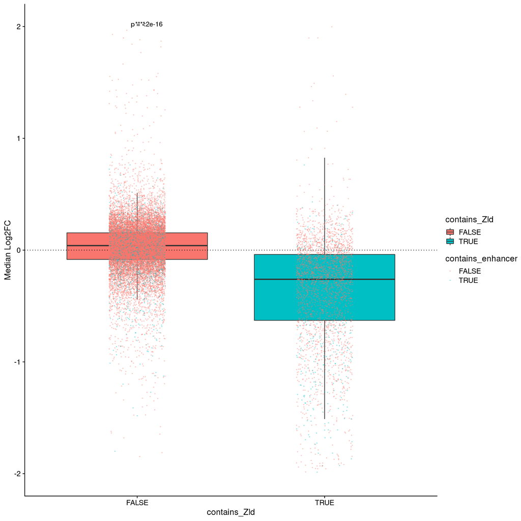

```r
library(matrixStats)

# Calculate mean and median log2FC and save this as a separate RDS

peaks_w_all_time_de_med.df<- peaks_w_all_time_de.df
med_log2fc <- rowMedians(as.matrix(peaks_w_all_time_de_med.df[,c(8:11)]))
ave_log2fc <- rowMeans(as.matrix(peaks_w_all_time_de_med.df[,c(8:11)]))
peaks_w_all_time_de_med.df$med_log2fc <- med_log2fc
peaks_w_all_time_de_med.df$ave_log2fc <- ave_log2fc

saveRDS(peaks_w_all_time_de_med.df, '/l/Zeitlinger/ZeitlingerLab/Manuscripts/Zelda_and_Nucleosomes/Analysis/data/deseq2/zldrnai/zld_depletion_deseq_timepoints_at_orer_1to3_atac_peaks_consolidated_single_df_w_med.RData')

# get motif information for the peaks

motif_info_for_peaks.df <- peaks_w_all_time_de_med.df %>%
  dplyr::left_join(., motifs.df %>% dplyr::select(c(pattern_name, peak_id)), by = 'peak_id') %>%
  group_by(peak_id) %>%
  dplyr::summarise(pattern_name = paste0(pattern_name, collapse = "-")) %>%
  dplyr::mutate(contains_Zld = grepl(pattern = 'Zld', x = pattern_name)) %>%
  as.data.frame

# merge peaks and motif information

peaks_w_all_time_de_med_motifs.df <- peaks_w_all_time_de_med.df %>%
  dplyr::left_join(., motif_info_for_peaks.df %>% dplyr::select(c(pattern_name, peak_id, contains_Zld)), by = 'peak_id') %>%
  dplyr::mutate(contains_enhancer = !is.na(enhancer_name))

# Plot

peaks_zldrnai_effect.plot <- ggplot(peaks_w_all_time_de_med_motifs.df, aes(x=contains_Zld, y=med_log2fc)) +
  geom_boxplot(aes(fill=contains_Zld), outlier.color = NA, outlier.fill = NA) +
  scale_y_continuous(name = "Median Log2FC", limits = c(-2,2))+
  geom_hline(yintercept = 0, linetype = 'dotted', color = 'black')+
  geom_jitter(width = 0.15, aes(color = contains_enhancer), size = 0.3, alpha = 0.3) +
  stat_compare_means(method = "wilcox.test", label = "p.signif") +
  stat_compare_means(method = "wilcox.test", label = "p.format") +
  theme_cowplot()
peaks_zldrnai_effect.plot
```

```r
ggsave("zldrnai_effect_at_all_atac_peaks.pdf", plot = peaks_zldrnai_effect.plot, path = "figures/14_zelda_depletion_atac", height = 10, width = 8)
ggsave("zldrnai_effect_at_all_atac_peaks.png", plot = peaks_zldrnai_effect.plot, path = "figures/14_zelda_depletion_atac", height = 10, width = 8)
```

# 6. Correlate observed Zld depeltion effect from DESeq2 with ChromBPNet model predictions

## 6.1. Import relevant data including island perturbations previously generated in 9_assign_genomic_perturb_scores.Rmd

```r
# island perturbs

islands_w_perturbs.gr <- readRDS("/l/Zeitlinger/ZeitlingerLab/Manuscripts/Zelda_and_Nucleosomes/Analysis/analysis/rdata/zld_containing_islands_w_zld_atac_perturbations.gr.rds")

# Zld motifs

zld_motifs.df <- readr::read_tsv('/l/Zeitlinger/ZeitlingerLab/Manuscripts/Zelda_and_Nucleosomes/Analysis/analysis/tsv/perturbs/accessibility/genomic/atac_overlapping_zld_0based.tsv.gz') %>%
  dplyr::left_join(.,
                   readr::read_tsv('/l/Zeitlinger/ZeitlingerLab/Manuscripts/Zelda_and_Nucleosomes/Analysis/analysis/tsv/mapped_motifs/all_instances_curated_1based_with_single_perturbs.tsv.gz') %>%
                     dplyr::select(motif_id, seq_match_p, seq_match),
                   by = 'motif_id')
```

## 6.2. Map AVERAGE Zelda PWM match %ile score across each island to account for multiple Zld motifs per island

```r
islands_w_perturbs.gr<-zld_motifs.df %>%
  dplyr::group_by(region_id) %>%
  dplyr::summarize(average_seq_match_p = mean(seq_match_p)) %>%
  dplyr::select(region_id, average_seq_match_p) %>%
  dplyr::left_join(islands_w_perturbs.gr %>% as.data.frame,
                   .,
                   by = 'region_id') %>%
  makeGRangesFromDataFrame(keep.extra.columns = T, starts.in.df.are.0based = F)
```

## 6.3. Map DESeq2 Log2FC values onto islands

```r
islands_vs_deseq_peaks.ov <- findOverlaps(islands_w_perturbs.gr, peaks.gr, ignore.strand = T)
islands_w_perturbs.gr$peak_id <- NA
islands_w_perturbs.gr$peak_id[islands_vs_deseq_peaks.ov@from] <- peaks.gr$peak_id[islands_vs_deseq_peaks.ov@to]

islands_w_perturbs_w_peaks.gr <- islands_w_perturbs.gr[!is.na(islands_w_perturbs.gr$peak_id)]

islands_across_peaks.df<-islands_w_perturbs.gr %>%
  as.data.frame() %>%
  dplyr::filter(!is.na(peak_id)) %>%
  dplyr::left_join(., peaks_w_all_time_de.df %>% dplyr::select(-c(seqnames, start, end, width, strand)), by = 'peak_id') %>%
  as.data.frame()
```

## 6.4. Calculate and plot

```r
# Calculate

islands_across_peaks.df$t1_log2FC_perturb_pred <- log2(islands_across_peaks.df$mut_pred_1to15/islands_across_peaks.df$wt_pred_1to15)
islands_across_peaks.df$t2_log2FC_perturb_pred <- log2(islands_across_peaks.df$mut_pred_15to2/islands_across_peaks.df$wt_pred_15to2)
islands_across_peaks.df$t3_log2FC_perturb_pred <- log2(islands_across_peaks.df$mut_pred_2to25/islands_across_peaks.df$wt_pred_2to25)
islands_across_peaks.df$t4_log2FC_perturb_pred <- log2(islands_across_peaks.df$mut_pred_25to3/islands_across_peaks.df$wt_pred_25to3)

# Plot

library(ggpubr)

islands_w_deseq_t1.plot <- ggplot(islands_across_peaks.df, aes(t1_log2FC,t1_log2FC_perturb_pred))+
  geom_hline(yintercept = 0, linetype = 'dotted', color = 'black')+
  geom_vline(xintercept = 0, linetype = 'dotted', color = 'black')+
  geom_point(aes(color = average_seq_match_p), size = .2)+
  geom_smooth(method = "lm", se=FALSE) +
  #stat_regline_equation(label.y = 0.2, aes(label = ..eq.label..)) +
  stat_regline_equation(label.y = 0.1, aes(label = ..rr.label..)) +
  ggpubr::stat_cor(method = 'pearson', label.x.npc = "right", label.y.npc = "bottom", hjust = 1, vjust = -.1)+
  ggtitle("Zld island genomic perturbations vs. Zld RNAi effect") +
  scale_x_continuous(name = 'log2(zldrnai_1to15/wt_1to15)')+
  scale_y_continuous(name = 'Predicted log2(zld-/wt) 1-1.5 hr')+
  scale_color_gradientn(colours = viridis::viridis(n=50, end = .95))+
  theme_cowplot()

islands_w_deseq_t2.plot <- ggplot(islands_across_peaks.df, aes(t2_log2FC,t2_log2FC_perturb_pred))+
  geom_hline(yintercept = 0, linetype = 'dotted', color = 'black')+
  geom_vline(xintercept = 0, linetype = 'dotted', color = 'black')+
  geom_point(aes(color = average_seq_match_p), size = .2)+
  geom_smooth(method = "lm", se=FALSE) +
  #stat_regline_equation(label.y = 0.2, aes(label = ..eq.label..)) +
  stat_regline_equation(label.y = 0.1, aes(label = ..rr.label..)) +
  ggpubr::stat_cor(method = 'pearson', label.x.npc = "right", label.y.npc = "bottom", hjust = 1, vjust = -.1)+
  ggtitle("Zld island genomic perturbations vs. Zld RNAi effect") +
  scale_x_continuous(name = 'log2(zldrnai_15to2/wt_15to2)')+
  scale_y_continuous(name = 'Predicted log2(zld-/wt) 1.5-2 hr')+
  scale_color_gradientn(colours = viridis::viridis(n=50, end = .95))+
  theme_cowplot()

islands_w_deseq_t3.plot <- ggplot(islands_across_peaks.df, aes(t3_log2FC,t3_log2FC_perturb_pred))+
  geom_hline(yintercept = 0, linetype = 'dotted', color = 'black')+
  geom_vline(xintercept = 0, linetype = 'dotted', color = 'black')+
  geom_point(aes(color = average_seq_match_p), size = .2)+
  geom_smooth(method = "lm", se=FALSE) +
  #stat_regline_equation(label.y = 0.2, aes(label = ..eq.label..)) +
  stat_regline_equation(label.y = 0.1, aes(label = ..rr.label..)) +
  ggpubr::stat_cor(method = 'pearson', label.x.npc = "right", label.y.npc = "bottom", hjust = 1, vjust = -.1)+
  ggtitle("Zld island genomic perturbations vs. Zld RNAi effect") +
  scale_x_continuous(name = 'log2(zldrnai_2to25/wt_2to25)')+
  scale_y_continuous(name = 'Predicted log2(zld-/wt) 2-2.5 hr')+
  scale_color_gradientn(colours = viridis::viridis(n=50, end = .95))+
  theme_cowplot()

islands_w_deseq_t4.plot <- ggplot(islands_across_peaks.df, aes(t4_log2FC,t4_log2FC_perturb_pred))+
  geom_hline(yintercept = 0, linetype = 'dotted', color = 'black')+
  geom_vline(xintercept = 0, linetype = 'dotted', color = 'black')+
  geom_point(aes(color = average_seq_match_p), size = .2)+
  geom_smooth(method = "lm", se=FALSE) +
  #stat_regline_equation(label.y = 0.2, aes(label = ..eq.label..)) +
  stat_regline_equation(label.y = 0.1, aes(label = ..rr.label..)) +
  ggpubr::stat_cor(method = 'pearson', label.x.npc = "right", label.y.npc = "bottom", hjust = 1, vjust = -.1)+
  ggtitle("Zld island genomic perturbations vs. Zld RNAi effect") +
  scale_x_continuous(name = 'log2(zldrnai_25to3/wt_25to3)')+
  scale_y_continuous(name = 'Predicted log2(zld-/wt) 2.5-3 hr')+
  scale_color_gradientn(colours = viridis::viridis(n=50, end = .95))+
  theme_cowplot()

islands_v_perturb.plot <- islands_w_deseq_t1.plot+islands_w_deseq_t2.plot+islands_w_deseq_t3.plot+islands_w_deseq_t4.plot

ggsave("islands_w_atac_effect_and_genomic_perturb_pearson.pdf", plot = islands_v_perturb.plot, path = "figures/14_zelda_depletion_atac", height = 10, width = 16)
ggsave("islands_w_atac_effect_and_genomic_perturb_pearson.png", plot = islands_v_perturb.plot, path = "figures/14_zelda_depletion_atac", height = 10, width = 16)
```